# Analysis of 'Learn HTML - Pro' App Reviews on Play-Store.

### By: Abdulrahman Hamzat

- Project Overview
- Dataset Summary
- Insights
- Summary of Analysis
- Limitations
- Conclusions and Recommendations

## Project Overview.

The reviews and ratings of "Learn HTML-Pro" app on playstore were extracted and analyzed. The entire project was carried out in four stages, and a separate notebook file for each one.  
Stage One: This involved the development of a Python script that can automatedly scrape the available ratings and reviews of any app on Play Store.  
Stage Two: Extraction of additional data, using Google-Play-Scraper, to supplement and validate the gathered data from stage one.  
Stage Three: Data integration, cleaning, and exploration.  
Stage Four: Presentation of visualizations and insights.

### Dataset Summary

#### Column Description

1. Review Id: A unique row identifier.
2. Username: Name of the app reviewer.
3. Star Rating: The count of star ratings given by a reviewer.
4. Date: Day, month and year of a review.
5. Review Content: Contains the texts of each review.
6. Thumbsup: The count of people that found a review helpful.
7. Device: Phone users or tablet users of the app.
8. App Version: The app version rated by a reviewer.
9. Sentiment Label: Contains positive or negative result of the sentiment analysis of a review.
10. Sentiment Score: Shows the corresponding score of the sentiment labels.

## Insights

### 1: What is the most frequent star rating of the app?

83.5% of the reviewers gave a 5-star rating making it the most frequent star. 10.7% of the reviewers gave a 4-star, while the least star ratings are 1 and 3. No reviewer from the dataset gave a 2-star rating.

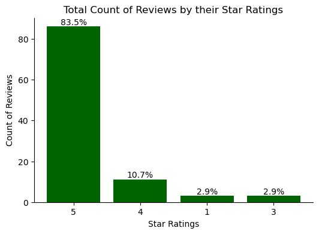

### 2: What release versions of the app got the most reviews?

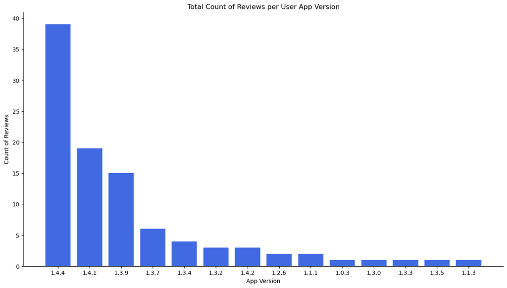

### 3: Does the app popularity increase yearly?

Yes, it does increases yearly up to year 2021. It maintained a relatively high count of reviews in year 2023 after a slight decrease in the previous year, then a sharp decline occured in 2024.

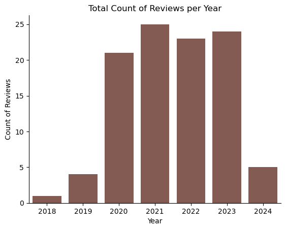

### 4: On what device type is the app most frequently installed?

A very high majority of installations are on phones compared to the very few installations on tablets.

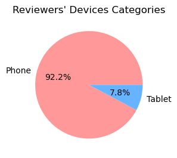

### 5: Are the users satisfied with the app?

The app users are quite satisfied with the app with 94.2% of the reviews being postive remarks. 5.8% of the reviewers were dissatisfied in years 2021 and 2022 only.

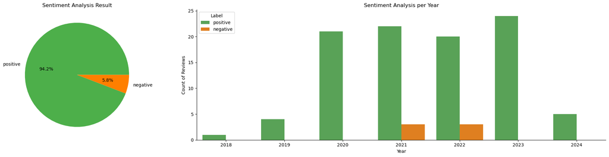

## Conclusions

Many subscribers of the app gave 5-star ratings, and even more wrote positive reviews signifying that the app users considered it great! Also, the app's popularity inreased over time and relatively high in the year 2020 through 2023, and it's mostly installed by phone users. Finally, there were negative reviews of the app in the year of its last update (2022) and the year before.

## Recommendations

The app developers should release new updates of the app to ensure its continuity and to boost its popularity as the latter appears to have declined in the year 2024.